# Untitled

Cedric KESSAHOU

2025-03-29

```r
library(tidyverse)
library(caret)
library(GGally)
```

```r
library(corrplot)
library(tidymodels)
library(car)  # Pour calculer le VIF
```

Chargement des donnée

```r
data <- read.csv('student_depression_dataset.csv')
```

Apercu des données

```r
head(data)
```

```
##   id Gender Age          City Profession Academic.Pressure Work.Pressure CGPA
## 1  2   Male  33 Visakhapatnam    Student                 5             0 8.97
## 2  8 Female  24     Bangalore    Student                 2             0 5.90
## 3 26   Male  31      Srinagar    Student                 3             0 7.03
## 4 30 Female  28      Varanasi    Student                 3             0 5.59
## 5 32 Female  25        Jaipur    Student                 4             0 8.13
## 6 33   Male  29          Pune    Student                 2             0 5.70
##   Study.Satisfaction Job.Satisfaction      Sleep.Duration Dietary.Habits
## 1                  2                0         '5-6 hours'        Healthy
## 2                  5                0         '5-6 hours'       Moderate
## 3                  5                0 'Less than 5 hours'        Healthy
## 4                  2                0         '7-8 hours'       Moderate
## 5                  3                0         '5-6 hours'       Moderate
## 6                  3                0 'Less than 5 hours'        Healthy
##    Degree Have.you.ever.had.suicidal.thoughts.. Work.Study.Hours
## 1 B.Pharm                                   Yes                3
## 2     BSc                                    No                3
## 3      BA                                    No                9
## 4     BCA                                   Yes                4
## 5  M.Tech                                   Yes                1
## 6     PhD                                    No                4
##   Financial.Stress Family.History.of.Mental.Illness Depression
## 1              1.0                               No          1
## 2              2.0                              Yes          0
## 3              1.0                              Yes          0
## 4              5.0                              Yes          1
## 5              1.0                               No          0
## 6              1.0                               No          0
```

```r
summary(data)
```

```
##        id            Gender               Age            City
##  Min.   :     2   Length:27901       Min.   :18.00   Length:27901
##  1st Qu.: 35039   Class :character   1st Qu.:21.00   Class :character
##  Median : 70684   Mode  :character   Median :25.00   Mode  :character
##  Mean   : 70442                      Mean   :25.82
##  3rd Qu.:105818                      3rd Qu.:30.00
##  Max.   :140699                      Max.   :59.00
##   Profession        Academic.Pressure Work.Pressure          CGPA
##  Length:27901       Min.   :0.000     Min.   :0.00000   Min.   : 0.000
##  Class :character   1st Qu.:2.000     1st Qu.:0.00000   1st Qu.: 6.290
##  Mode  :character   Median :3.000     Median :0.00000   Median : 7.770
##                     Mean   :3.141     Mean   :0.00043   Mean   : 7.656
##                     3rd Qu.:4.000     3rd Qu.:0.00000   3rd Qu.: 8.920
##                     Max.   :5.000     Max.   :5.00000   Max.   :10.000
##  Study.Satisfaction Job.Satisfaction   Sleep.Duration     Dietary.Habits
##  Min.   :0.000      Min.   :0.000000   Length:27901       Length:27901
##  1st Qu.:2.000      1st Qu.:0.000000   Class :character   Class :character
##  Median :3.000      Median :0.000000   Mode  :character   Mode  :character
##  Mean   :2.944      Mean   :0.000681
##  3rd Qu.:4.000      3rd Qu.:0.000000
##  Max.   :5.000      Max.   :4.000000
##     Degree          Have.you.ever.had.suicidal.thoughts.. Work.Study.Hours
##  Length:27901       Length:27901                          Min.   : 0.000
##  Class :character   Class :character                      1st Qu.: 4.000
##  Mode  :character   Mode  :character                      Median : 8.000
##                                                           Mean   : 7.157
##                                                           3rd Qu.:10.000
##                                                           Max.   :12.000
##  Financial.Stress   Family.History.of.Mental.Illness   Depression
##  Length:27901       Length:27901                     Min.   :0.0000
##  Class :character   Class :character                 1st Qu.:0.0000
##  Mode  :character   Mode  :character                 Median :1.0000
##                                                      Mean   :0.5855
##                                                      3rd Qu.:1.0000
##                                                      Max.   :1.0000
```

```r
data<- data %>%
  select(- id, -City, -Profession, -Work.Pressure, -Job.Satisfaction, - Degree)
```

```r
head(data)
```

```
##   Gender Age Academic.Pressure CGPA Study.Satisfaction      Sleep.Duration
## 1   Male  33                 5 8.97                  2         '5-6 hours'
## 2 Female  24                 2 5.90                  5         '5-6 hours'
## 3   Male  31                 3 7.03                  5 'Less than 5 hours'
## 4 Female  28                 3 5.59                  2         '7-8 hours'
## 5 Female  25                 4 8.13                  3         '5-6 hours'
## 6   Male  29                 2 5.70                  3 'Less than 5 hours'
##   Dietary.Habits Have.you.ever.had.suicidal.thoughts.. Work.Study.Hours
## 1        Healthy                                   Yes                3
## 2       Moderate                                    No                3
## 3        Healthy                                    No                9
## 4       Moderate                                   Yes                4
## 5       Moderate                                   Yes                1
## 6        Healthy                                    No                4
##   Financial.Stress Family.History.of.Mental.Illness Depression
## 1              1.0                               No          1
## 2              2.0                              Yes          0
## 3              1.0                              Yes          0
## 4              5.0                              Yes          1
## 5              1.0                               No          0
## 6              1.0                               No          0
```

Vérification des valeurs manquantes

```r
total_na <- sum(is.na(data))
cat ('Nombre total de valeurs manquantes:', total_na, '\n')
```

```
## Nombre total de valeurs manquantes: 0
```

Convertissons les variables catégoriques en facteur

```r
data$Gender <- as.factor(data$Gender)
data$Sleep.Duration <- as.factor(data$Sleep.Duration)
data$Dietary.Habits <- as.factor(data$Dietary.Habits)
data$Have.you.ever.had.suicidal.thoughts..<- as.factor(data$Have.you.ever.had.suicidal.thoughts..)
data$Family.History.of.Mental.Illness <- as.factor(data$Family.History.of.Mental.Illness)
data$Depression <- as.factor(data$Depression)
```

On convertir les variables suivant en binaire pour pouvoir les intégré a la matrice de correlation

```r
data$Gender <- ifelse(data$Gender == "Male", 0, 1)  # ou "Female" = 1
data$Family.History.of.Mental.Illness <- ifelse(data$Family.History.of.Mental.Illness == "Yes", 1, 0)
data$Depression <- as.numeric(as.character(data$Depression))
```

#Attention Nous n’avons pas intégré les variables Dietary.Habits et Sleep.Duration parceque leurs intégration nécessitera leurs conversion en binaire ce qui impliquera une perte d’Information jugé important et qui pourrait introduire un biais surtout avec la repartion des valeurs suivantes qu’ils affiche. Sleep Duration: « Moins de 5 heures » → 30%, « 7 à 8 heures » → 26% et Autres → 44% et Dietary Habits : Malsain → 37%, Modéré → 36% et Autre (probablement « Healthy ») → 27%

Visualisons les correlations entre les variables numériques

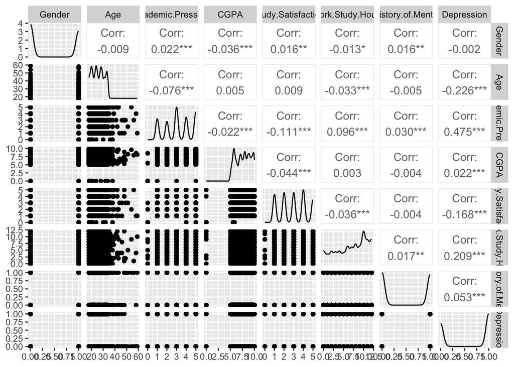

```r
variable_numerique<- data%>%
  select_if(is.numeric)
 ggpairs(variable_numerique)
```

Matrice de correlation

```r
cor_matrix <- cor(variable_numerique, use = "complete.obs")
```

Affichage de la heatmap

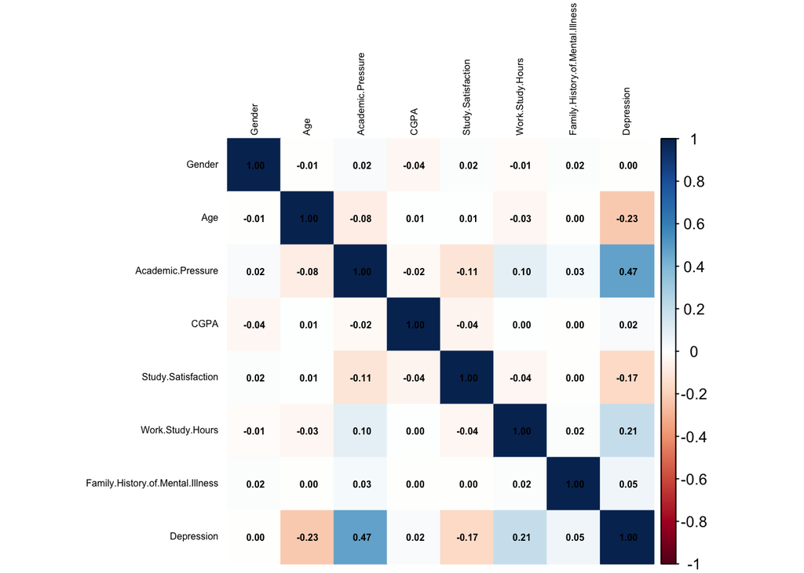

```r
corrplot(cor_matrix, method="color", tl.cex=0.5, tl.col="black", addCoef.col="black", number.cex=0.5)
```

On remarque une corelation positive entre academique pressure et la depression et entre le nombre d’heure d’etude et la depression

#Regression lineaire

Divisons notre ensemble d’entrainement et de test

```r
set.seed(123)
train_index<- sample(seq_len(nrow(data)), size= 0.8 * nrow(data))
train_data <-data[train_index, ]
test_data <- data[-train_index, ]
```

```r
head((train_data))
```

```
##       Gender Age Academic.Pressure CGPA Study.Satisfaction      Sleep.Duration
## 18847      0  25                 3 6.33                  4         '5-6 hours'
## 18895      0  29                 3 8.28                  5         '5-6 hours'
## 26803      1  20                 3 8.95                  2 'Less than 5 hours'
## 25102      1  19                 5 7.64                  2 'Less than 5 hours'
## 2986       1  28                 1 5.32                  3 'More than 8 hours'
## 1842       0  28                 4 5.25                  2         '5-6 hours'
##       Dietary.Habits Have.you.ever.had.suicidal.thoughts.. Work.Study.Hours
## 18847      Unhealthy                                    No               11
## 18895      Unhealthy                                   Yes                6
## 26803       Moderate                                    No                2
## 25102       Moderate                                   Yes               10
## 2986         Healthy                                    No               12
## 1842        Moderate                                   Yes                1
##       Financial.Stress Family.History.of.Mental.Illness Depression
## 18847              5.0                                0          1
## 18895              1.0                                1          0
## 26803              3.0                                1          1
## 25102              4.0                                1          1
## 2986               4.0                                0          0
## 1842               4.0                                1          1
```

Entrainement du model de regression lineaire

```r
model <- lm (Depression ~ ., data = train_data)
```

#Resumé du modele

```r
summary(model)
```

```
##
## Call:
## lm(formula = Depression ~ ., data = train_data)
##
## Residuals:
##      Min       1Q   Median       3Q      Max
## -1.14286 -0.20299  0.02073  0.22376  1.16596
##
## Coefficients:
##                                            Estimate Std. Error t value Pr(>|t|)
## (Intercept)                               0.3757680  0.2430665   1.546 0.122132
## Gender                                   -0.0032143  0.0046332  -0.694 0.487842
## Age                                      -0.0130417  0.0004727 -27.589  < 2e-16
## Academic.Pressure                         0.1093224  0.0017456  62.628  < 2e-16
## CGPA                                      0.0056206  0.0015594   3.604 0.000314
## Study.Satisfaction                       -0.0291613  0.0017026 -17.128  < 2e-16
## Sleep.Duration'7-8 hours'                 0.0098376  0.0066050   1.489 0.136393
## Sleep.Duration'Less than 5 hours'         0.0394697  0.0064561   6.114 9.91e-10
## Sleep.Duration'More than 8 hours'        -0.0304871  0.0069472  -4.388 1.15e-05
## Sleep.DurationOthers                      0.0172005  0.0951002   0.181 0.856474
## Dietary.HabitsModerate                    0.0669339  0.0058322  11.477  < 2e-16
## Dietary.HabitsOthers                      0.1026632  0.1033628   0.993 0.320608
## Dietary.HabitsUnhealthy                   0.1317419  0.0058452  22.538  < 2e-16
## Have.you.ever.had.suicidal.thoughts..Yes  0.3809990  0.0050788  75.017  < 2e-16
## Work.Study.Hours                          0.0140714  0.0006252  22.508  < 2e-16
## Financial.Stress1.0                      -0.3346874  0.2422178  -1.382 0.167059
## Financial.Stress2.0                      -0.2728626  0.2422226  -1.126 0.259968
## Financial.Stress3.0                      -0.1892805  0.2422225  -0.781 0.434556
## Financial.Stress4.0                      -0.1244328  0.2422210  -0.514 0.607456
## Financial.Stress5.0                      -0.0618842  0.2422186  -0.255 0.798348
## Family.History.of.Mental.Illness          0.0263837  0.0045945   5.742 9.46e-09
##
## (Intercept)
## Gender
## Age                                      ***
## Academic.Pressure                        ***
## CGPA                                     ***
## Study.Satisfaction                       ***
## Sleep.Duration'7-8 hours'
## Sleep.Duration'Less than 5 hours'        ***
## Sleep.Duration'More than 8 hours'        ***
## Sleep.DurationOthers
## Dietary.HabitsModerate                   ***
## Dietary.HabitsOthers
## Dietary.HabitsUnhealthy                  ***
## Have.you.ever.had.suicidal.thoughts..Yes ***
## Work.Study.Hours                         ***
## Financial.Stress1.0
## Financial.Stress2.0
## Financial.Stress3.0
## Financial.Stress4.0
## Financial.Stress5.0
## Family.History.of.Mental.Illness         ***
## ---
## Signif. codes:  0 '***' 0.001 '**' 0.01 '*' 0.05 '.' 0.1 ' ' 1
##
## Residual standard error: 0.3424 on 22299 degrees of freedom
## Multiple R-squared:  0.5176, Adjusted R-squared:  0.5172
## F-statistic:  1196 on 20 and 22299 DF,  p-value: < 2.2e-16
```

#Prediction sur l’ensemble de test

```r
predictions<- predict(model, newdata = test_data)

test_resultats<- data.frame(Observé= test_data$Depression, Prédit = predictions)

print(test_resultats)
```

[output not shown]

[output cut: 5567 more lines]

Evaluation des performances

```r
rmse <- sqrt(mean((test_resultats$Observé - test_resultats$Prédit)^2))
rsq <- cor(test_resultats$Observé, test_resultats$Prédit)^2

cat('RMSE :', rmse, '\n')
```

```
## RMSE : 0.3426287
```

```r
cat('R² :', rsq, '\n')
```

```
## R² : 0.5157465
```

#Regression logistique

```r
logit_model <- glm(Depression ~ ., data = train_data, family = "binomial")
```

```r
logit_pred <- predict(logit_model, newdata = test_data, type = "response")  # donne une proba

# Convertir les proba en classes (si besoin)
logit_class <- ifelse(logit_pred >= 0.5, 1, 0)
```

```r
resultats <- data.frame(Observé = test_data$Depression, Probabilité = logit_pred)
head(resultats)
```

```
##    Observé Probabilité
## 1        1  0.55347476
## 6        0  0.01340688
## 8        0  0.02413974
## 12       0  0.45467912
## 29       0  0.58493850
## 34       0  0.03266074
```

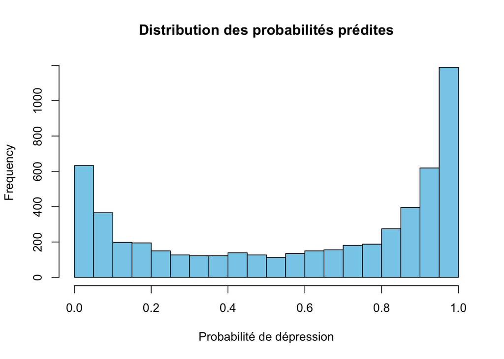

```r
hist(logit_pred,
     breaks = 30,
     col = "skyblue",
     main = "Distribution des probabilités prédites",
     xlab = "Probabilité de dépression")
```

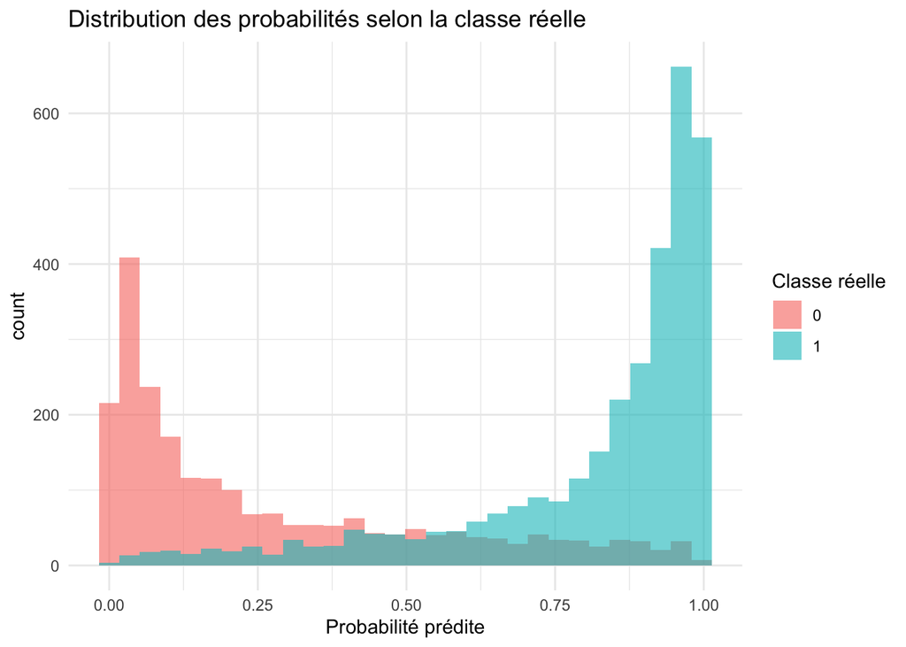

```r
library(ggplot2)

resultats$Classe <- as.factor(test_data$Depression)

ggplot(resultats, aes(x = Probabilité, fill = Classe)) +
  geom_histogram(position = "identity", alpha = 0.6, bins = 30) +
  labs(title = "Distribution des probabilités selon la classe réelle",
       x = "Probabilité prédite", fill = "Classe réelle") +
  theme_minimal()
```

```r
# Prédiction binaire avec un seuil de 0.5
pred_class <- ifelse(logit_pred >= 0.5, 1, 0)

# Matrice finale pour évaluation
resultats$Prédit <- pred_class
head(resultats)
```

```
##    Observé Probabilité Classe Prédit
## 1        1  0.55347476      1      1
## 6        0  0.01340688      0      0
## 8        0  0.02413974      0      0
## 12       0  0.45467912      0      0
## 29       0  0.58493850      0      1
## 34       0  0.03266074      0      0
```